# Practice Git and Functional Programming

Nishant Kishore

2024-02-05

# The challenge

Given the synthetic datasets below, we want to build a suite of functions which will allow us to create a quick and reliable visualization of the data. This will require three key functions.

1. `interpolate_pop()`: Convert population data from wide to long and interpolate missing data for years where data is unavailable.

*Description*: Takes in wide incomplete population data and turns it into long form with interpolated data along a range.

*Params*:

- `pop_data` Wide population data from census with only certain years provided
- `start.year` an integer for the first year of data to begin interpolation
- `end.year` an integer for the last year of data to end interpolation

*Returns*: A tibble with variables `state`, `county`, `year`, `pop`

2. `add_npafp_data()`: Takes in a plot object and returns a ggplot map with npafp rate data attached.

*Description*: Takes in a plot object adds npafp data and returns a facet wrapped plot object depending on start and end year.

*Params*

-`input_plot` a ggplot object to be passed in. In this case it is base_plot

-`spatial_data` a sf object with variables to join in data from pop

-`afp_data` a tibble object loading afp information

-`pop_data` a tibble object with pop data in long format

-`start.year` an integer for the first year of data to begin interpolation

-`end.year` an integer for the last year of data to end interpolation

*Returns*: A ggplot object

3. `add_es_sites()`: Takes in a plot object and returns a ggplot map with ES sites added to it.

*Description*: Takes in ES data and merges it to spatial files. Filters ES data based off of having at least a minimum number of collections and portrayed on the map with different symbols for each type and only the years requested

*Params*:

- `input_plot` a ggplot object to be passed in. In this case it is base_plot
- `es_sites` a spatial points dataset with information about sites
- `es_data` a tibble with information on sites years and # of collections
- `min.coll` an integer describing the minimum number of collections to include a site
- `start.year` an integer for the first year of data to begin interpolation
- `end.year` an integer for the last year of data to end interpolation

*Returns*: a ggplot object

We will begin with this base plot and add pieces to it:

```r
#load up all of our data files of interest
ga_state <- read_rds(here("sections/1/data/ga_sf.rds"))
ga_counties <- read_rds(here("sections/1/data/ga_counties_sf.rds"))
us_pop <- read_rds(here("sections/1/data/us_pop.rds"))
afp_data <- read_rds(here("sections/1/data/afp.rds"))
es_sites <- read_rds(here("sections/1/data/es_sites.rds"))
es_data <- read_rds(here("sections/1/data/es_data.rds"))

base_plot <- ggplot() +
  geom_sf(data = ga_state, fill = NA) +
  theme_void()
```

Our goal is to be able to successfully run this series of commands:

```r
#load up all the functions we've created
list.files(here("sections/1/R"), full.names = T) |>
  sapply(source)
```

[output not shown]

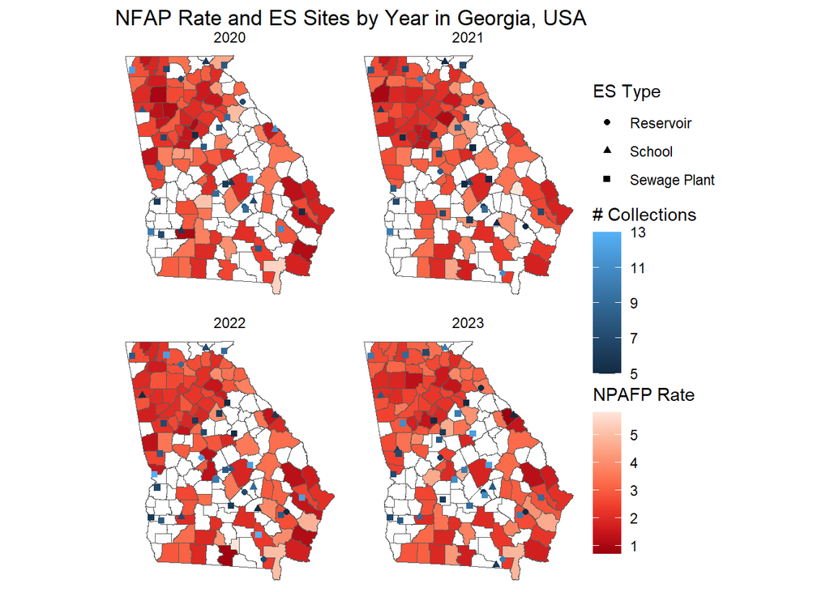

```r
plot1 <- add_npafp_data(
    input_plot = base_plot,
    afp_data = afp_data,
    spatial_data = ga_counties,
    pop_data = interpolate_pop(pop_data, start.year = 2020, end.year = 2023),
    start.year = 2020,
    end.year = 2023
    )
plot2 <- add_es_sites(
  input_plot = plot1,
    es_sites = es_sites,
    es_data = es_data,
    min.coll = 5,
    start.year = 2020,
    end.year = 2023
    )

plot2 +
  labs(title = "NFAP Rate and ES Sites by Year in Georgia, USA",
       fill = "NPAFP Rate",
       color = "# Collections",
       shape = "ES Type")
```

# How did I create this dataset?

## Data Sources

```r
#I've added in package tags in locations where sources may not be obvious
#shapes pulled from the tigris package
states <- tigris::states()
counties <- tigris::counties()
ga_state <- states |> filter(NAME == "Georgia")
ga_counties <- counties |> filter(STATEFP == ga_state$STATEFP)

write_rds(ga_state, here("sections/1/data/ga_sf.rds"))
write_rds(ga_counties, here("sections/1/data/ga_counties_sf.rds"))

#pop data pulled from the usdata package
us_pop <- tibble(usdata::county_complete) |>
  select(state, county = name, starts_with("pop")) |>
  filter(state == "Georgia")
write_rds(us_pop, here("sections/1/data/us_pop.rds"))
```

```r
#loading data
ga_state <- read_rds(here("sections/1/data/ga_sf.rds"))
ga_counties <- read_rds(here("sections/1/data/ga_counties_sf.rds"))
us_pop <- read_rds(here("sections/1/data/us_pop.rds"))

#create fake AFP data
us_pop |>
  #convert wide to long
  pivot_longer(starts_with("pop"), names_to = "year", names_prefix = "pop") |>
  #this only contains a few years of data so we can linearly extrapolate
  #to fill in the rest
  mutate(
    year = str_replace(year, "_", ""),
    year = as.numeric(year)
  ) %>%
  #everything inide the {} below references the output above as '.'
  {
    #bind full years of data with fitted full years
    bind_cols(
      #create the "fake" dataset
      expand_grid(
        state = "Georgia",
        county = unique(.$county),
        year = 2016:2023),
      "fit_pop" = predict.lm(
        #linear model specific for  year and county
        object = lm(value ~ year + county, data = .),
        #producing the same newdata as above
        newdata = expand_grid(
          state = "Georgia",
          county = unique(.$county),
          year = 2016:2023)
        )
      )
    } |>
  mutate(fit_pop = round(fit_pop, 0)) |>
  rowwise() |>
  mutate(npafp = rnorm(n = 1, mean = 2, sd = 0.5)) |>
  ungroup() |>
  mutate(n_afp = round(npafp/100000*fit_pop, 0)) |>
  filter(n_afp > 0) |>
  select(state, county, year, n_afp) |>
  uncount(n_afp) |>
  rowwise() |>
  mutate(month = sample(1:12,1),
         day = sample(1:28,1)) |>
  ungroup() |>
  mutate(date = as_date(paste0(year, "-", month, "-", day))) |>
  select(state, county, date) |>
  mutate(classification = "NPAFP") |>
  write_rds(here("sections/1/data/afp.rds"))

#creating example "long" pop dataset
us_pop |>
  #convert wide to long
  pivot_longer(starts_with("pop"), names_to = "year", names_prefix = "pop") |>
  #this only contains a few years of data so we can linearly extrapolate
  #to fill in the rest
  mutate(
    year = str_replace(year, "_", ""),
    year = as.numeric(year)
  ) %>%
  #everything inide the {} below references the output above as '.'
  {
    #bind full years of data with fitted full years
    bind_cols(
      #create the "fake" dataset
      expand_grid(
        state = "Georgia",
        county = unique(.$county),
        year = 2016:2023),
      "fit_pop" = predict.lm(
        #linear model specific for  year and county
        object = lm(value ~ year + county, data = .),
        #producing the same newdata as above
        newdata = expand_grid(
          state = "Georgia",
          county = unique(.$county),
          year = 2016:2023)
        )
      )
    } |>
  mutate(pop = round(fit_pop, 0)) |>
  write_rds(here("sections/1/data/ex_long_pop.rds"))

#generate ES sites
ga_state |>
  st_sample(40) |>
  st_as_sf() |>
  mutate("site_id" = row_number()) |>
  rowwise() |>
  mutate(type = sample(size = 1, c("School", "Sewage Plant", "Reservoir"), prob = c(0.2,0.7,0.1))) |>
  ungroup() |>
  rename(SHAPE = x) |>
  write_rds(here("sections/1/data/es_sites.rds"))

#generate ES yearly data
read_rds(here("sections/1/data/es_sites.rds")) |>
  tibble() %>%
  {lapply(2016:2023, function(x) mutate(., year = x))} |>
  bind_rows() |>
  rowwise() |>
  mutate(n_collections = rpois(1, 7)) |>
  ungroup() |>
  sample_frac(size = 0.9) |>
  select(site_id, type, year, n_collections) |>
  write_rds(here("sections/1/data/es_data.rds"))

rm(list = ls())
```